# Jack Mackerel Assessment Workshop

Day Two: Understanding Model Outputs

07 June 2022

# Main Objective

- Understand the components of a jjm output object
- Be able to make individual plots using the `jjmR` package
- Be able to make custom plots using jjm model outputs

# Output Files

Once you’ve successfully run the assessment model for `h1` and `h2`, these are the files you should have (assuming you selected the `pdf=TRUE` option in the `runit()` function).

```r
- h1_1.00_1_R.rep # Named report file that is read directly as a list into R
- h1_1.00.cor # Parameter correlation matrix
- h1_1.00.par # Best estimates of the parameters within the model
- h1_1.00.pdf # PDF of plots
- h1_1.00.rep # Predicted quantities
- h1_1.00.std # Estimated parameter values and standard deviations
- h1_1.00.yld # Profile of stock, yield, and recruitment over F

---

- h2_1.00_1_R.rep
- h2_1.00_2_R.rep # Note second R.rep file for the second stock
- h2_1.00.cor
- h2_1.00.par
- h2_1.00.pdf
- h2_1.00.rep
- h2_1.00.std
- h2_1.00.yld
```

The `readJJM()` function only requires a subset of these files to work:

```
- R.rep
- .par
- .rep
- .std
- .yld
```

# Reading the Output into R

- We have already most of this code for this in the Input Files doc.

```r
library(jjmR)

h1.mod <- readJJM("h1_1.00", path = "config", input = "input")

h2.mod <- readJJM("h2_1.00",path = "config", input = "input")

names(h1.mod[[1]]$output[[1]])
```

```
##   [1] "repl_yld"                        "repl_SSB"
##   [3] "FW_N_Chile"                      "FW_SC_Chile_PS"
##   [5] "FW_Offshore_Trawl"               "FW_Chile_AcousCS"
##   [7] "FW_Chile_AcousN"                 "FW_DEPM"
##   [9] "M"                               "q_1"
##  [11] "q_2"                             "q_3"
##  [13] "q_4"                             "q_5"
##  [15] "q_6"                             "q_7"
##  [17] "SurvNextYr"                      "Yr"
##  [19] "P_age2len_1"                     "len_bins"
##  [21] "TotF"                            "TotBiom_NoFish"
##  [23] "SSB_NoFishR"                     "TotBiom"
##  [25] "SSB_fut_1"                       "SSB_fut_2"
##  [27] "SSB_fut_3"                       "SSB_fut_4"
##  [29] "SSB_fut_5"                       "Catch_fut_1"
```

[output cut: 89 more lines]

- These names correspond to values in the TPL file, so you can search that if you get stuck.
- JC Quiroz wrote a script that pulls out quantities to make the tables in the technical annex (`jjm/assessment/R/constructor_input_tables.R`)

## Things to Note

- One of the most important tables (in my opinion) in the output object is `msy_mt`. It contains a matrix with the time series of derived quantities and estimated reference points.
  - Note to self: Set colnames in jjmR output function for this table

```r
# // Yr Fspr 1-Fspr F/Fmsy Fmsy F Fsprmsy MSY MSYL Bmsy Bzero SSB B/Bmsy

h1.mod[[1]]$output[[1]]$msy_mt
```

```
##       [,1]    [,2]    [,3]    [,4]    [,5]    [,6]    [,7]      [,8]    [,9]
##  [1,] 1970 0.90269 0.09731 0.08481 0.13462 0.01142 0.38878  737.4146 0.29370
##  [2,] 1971 0.85922 0.14078 0.12664 0.13488 0.01708 0.38725  744.0090 0.29193
##  [3,] 1972 0.90486 0.09514 0.08237 0.13454 0.01108 0.37937  778.2772 0.28283
##  [4,] 1973 0.86996 0.13004 0.11584 0.13322 0.01543 0.37210  823.1915 0.27442
##  [5,] 1974 0.78906 0.21094 0.20793 0.12391 0.02576 0.37136  900.6712 0.27357
##  [6,] 1975 0.77601 0.22399 0.21621 0.13447 0.02907 0.38204  759.2881 0.28591
##  [7,] 1976 0.73326 0.26674 0.26736 0.13485 0.03605 0.38193  786.9278 0.28578
##  [8,] 1977 0.62494 0.37506 0.44509 0.11550 0.05141 0.37540  916.6952 0.27824
##  [9,] 1978 0.51907 0.48093 0.61387 0.13036 0.08003 0.37514  792.1635 0.27794
## [10,] 1979 0.46831 0.53169 0.77664 0.12878 0.10001 0.39767  822.8119 0.30397
## [11,] 1980 0.50737 0.49263 0.66866 0.12768 0.08538 0.39176  911.8942 0.29715
## [12,] 1981 0.39879 0.60121 0.97379 0.13224 0.12877 0.39158  883.8071 0.29694
## [13,] 1982 0.30065 0.69935 1.52351 0.14224 0.21671 0.39363  734.4643 0.29931
## [14,] 1983 0.36044 0.63956 1.30603 0.13141 0.17162 0.42299  801.8153 0.33323
```

[output cut: 91 more lines]

- `FW_*` denotes the Francis Weights for each fleet.

```r
$FW_N_Chile
0.915323
$FW_SC_Chile_PS
0.910934
$FW_Offshore_Trawl
0.681234
$FW_Chile_AcousCS
0.92536
$FW_Chile_AcousN
0.91344
$FW_DEPM
1.07482
```

- `SSB_fut_1` to `SSB_fut_5` denotes future spawning stock biomass projected under five different fishing scenarios (more on this later).

# Making Plots

- The PDF generated by `runit()` generally contains all the plots
- The `diagnostics` function generates plots from the jjm object.

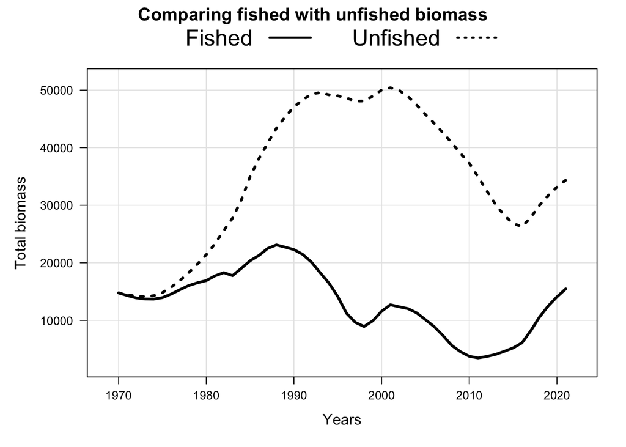

```r
# Setting plot=T will create the entire suite of plots
h1.diag <- diagnostics(h1.mod, plot=F)

h2.diag <- diagnostics(h2.mod, plot=F)

#You can then plot individual plots by changing the `var` variable
plot(h1.diag, var = "fishedUnfishedBiomass")
```

[figure not shown]

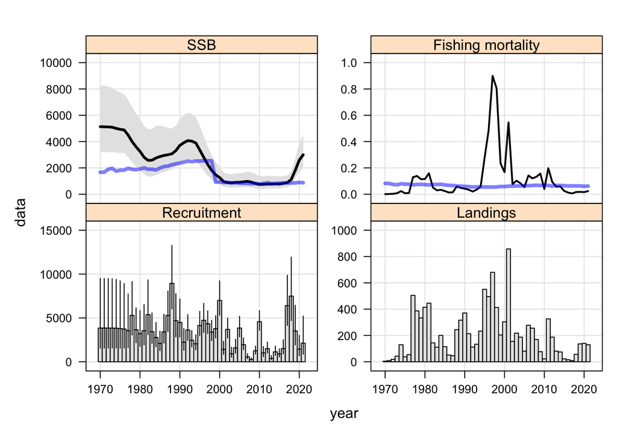

```r
plot(h2.diag, var = "summarySheet")
```

- You can find the different `var` options deep within the jjmR [code](https://github.com/SPRFMO/jjmr/blob/master/R/jjm.diag-internal.R)
  - Might be worth documenting separately?
- Examples can also be found in `jjm/assessment/R/AnnexPlots.R`

# Exercises

- Pick two plots from the technical annex and make them from scratch
  - Find the variables using `names(h1.mod[[1]]$output[[1]])`
  - Do this for `h1` and `h2`
  - Bonus if you can graph them creatively
- Think of suggestions for other diagnostic plots we can use?